# COSMOS Analysis: data preparation for CARNIVAL

A. Gabor

9/9/2020

## Metabolomics import

Import the metabolomics data:

```r
metabolomics = import_metabolomics()
print(head(metabolomics,10))
```

```
## # A tibble: 10 x 11
##    `sorting index` `ion m/z` `possible annot… `HMDB ID` `PubChem ID` `KEGG ID`
##              <dbl>     <dbl> <chr>            <chr>            <dbl> <chr>
##  1            6284      309. D-Erythroascorb… HMDB33627           NA <NA>
##  2            5907      289. <NA>             <NA>                NA <NA>
##  3            4691      241. L-Cystine        HMDB00192        67678 C00491
##  4            2286      165. 5-Fluorouracil … HMDB31425           NA <NA>
##  5            6952      346. Sucrose 1',4'-(… HMDB36978           NA <NA>
##  6            6953      346. Licorice glycos… HMDB31996           NA <NA>
##  7            3293      191. Oxalosuccinic a… HMDB03974          972 C05379
##  8            1015      129. 5-Fluorouracil … HMDB31425           NA <NA>
##  9            4801      245. Isopimpinellin   HMDB34312        68079 C02162
## 10            4802      245. Coriandrone C    HMDB41525           NA <NA>
## # … with 5 more variables: sample_id <chr>, `log2 fc` <dbl>, `p-value` <dbl>,
## #   `q-value (FDR)` <dbl>, organ <chr>
```

## Subsetting metabolomics data to prior knowledge

Import meta prior knowledge, built from Omnipath and metabolomics interaction.

```r
meta_pkn <- read_csv(file = "./data/meta_prior_knowledge/meta_network_carnival_ready_exch_solved_fullomni_metfiltered.csv")
```

the pkn contains compartment information: not all reactions happen in all compartments. But we dont have this info in the data. We will assume that the measured metaolites could appear in any compartment. Then we filter for the measurements that appear in the prior knowledge.

```r
cosmos_pubchem_id <- prepare_metabolomics_names(metabolomics$`PubChem ID`,meta_pkn)
```

In total 8912 unique ions were identified across samples, 2538 has a valid pubchemID that we used to map the data to prior knowledge. The 2538 metabolites were significantly changed in total 7778 times across conditions (q-value < 0.05).

Finally, 391 unique metabolite can be found in the prior knowledge network, they were found significant in total 1518 times across all conditions.

```r
# we attach the generated cosmosIDs and filter for data that is in PKN
metabolomics_in_pkn <- metabolomics %>% rename(pubchemID = `PubChem ID`) %>%
    right_join(cosmos_pubchem_id,by = "pubchemID")
```

```r
write_rds(metabolomics_in_pkn,"data/carnival_inputs/human_metabolomics_data.rds")
```

## Subsetting Transcription factor data to PKN

We estimated the transcription factor activity, now we adjust the names to COSMOS and filter for TFS that appear in the PKN.

```r
tf_activity <- read_rds("./data/results/tf_activity_gviper_all_human.rds")


tf_activity <- tf_activity %>%
    mutate(cosmosID = gene_symbols_to_entrez(tf)) %>%
    mutate(cosmosID = paste0("X",cosmosID))
```

Filter TFs that are not in prior knowledge network or which activity changed less than 1.96 (threshold for .95 percentile of normal distribution, two-sided).

```r
tf_in_pkn = tf_activity %>%
    filter(abs(activity) > 1.96) %>%
    filter(cosmosID %in% c(meta_pkn$source,meta_pkn$target))

total_tf_estimated = length(unique(tf_activity$tf))
total_tf_in_pkn = length(unique(tf_in_pkn$tf))
```

In total we had 113 estimated transcription factors and found 88 of them in the PKN with strong change.

```r
write_rds(tf_in_pkn,"data/carnival_inputs/human_tf_data.rds")
```

## Subsetting prior knowledge based on expressed genes

We remove the nodes from the prior knowledge network if the nodes is a gene, which is not expressed in the tissue.

First we need to find the genes that are not expressed across samples.

```r
sample_meta_SI <- read_tsv("./data/5-FU in vitro human/transcriptomics/SI/raw/metadata.txt")
raw_count_human_SI <- read_tsv("./data/5-FU in vitro human/transcriptomics/SI/raw/gene_count.txt") %>%
    dplyr::rename(gene_ensembl_id = X1)

sample_meta_colon <- read_tsv("./data/5-FU in vitro human/transcriptomics/colon/raw/metadata.txt") %>%
    dplyr::rename(name = "X1")
raw_count_human_colon <- read_tsv("./data/5-FU in vitro human/transcriptomics/colon/raw/gene_expected_count.txt") %>%
    dplyr::rename(gene_ensembl_id = "gene_id")


# add entrez id
raw_count_human_SI <- raw_count_human_SI %>%
    mutate(entrezID = gene_ensembl_to_entrez(gene_ensembl_id)) %>%
    dplyr::select(gene_ensembl_id,entrezID,everything())

raw_count_human_colon <- raw_count_human_colon %>%
    mutate(entrezID = gene_ensembl_to_entrez(gene_ensembl_id)) %>%
    dplyr::select(gene_ensembl_id,entrezID,everything())



# identify genes to keep:
keep_SI <- find_unexpressed_genes(raw_count_human_SI[,-1:-2], sample_meta_SI)
keep_colon <- find_unexpressed_genes(raw_count_human_colon[,-1:-2], sample_meta_colon)

# merge to data
raw_count_human_SI <- raw_count_human_SI %>%
    add_column(keep = keep_SI, .before = 3)
raw_count_human_colon <- raw_count_human_colon %>%
    add_column(keep = keep_colon, .before = 3)
```

We compute the distribution of gene expression and show which part is removed.

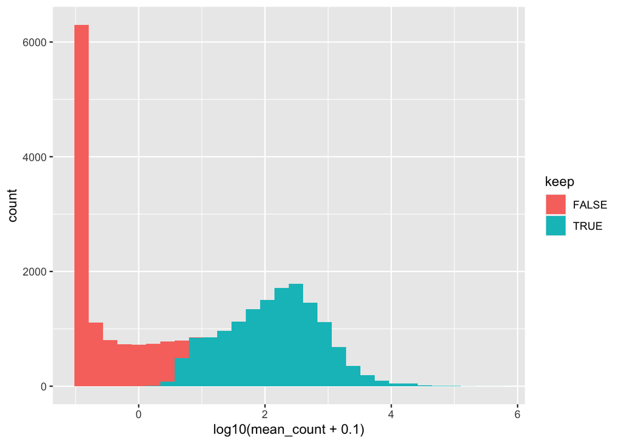

```r
raw_count_human_SI %>%
    gather(sample,count,starts_with("Sample_")) %>%
    group_by(entrezID, keep) %>%
    summarise(mean_count = mean(count)) %>%
    ggplot() + geom_histogram(aes(log10(mean_count+0.1), fill=keep))
```

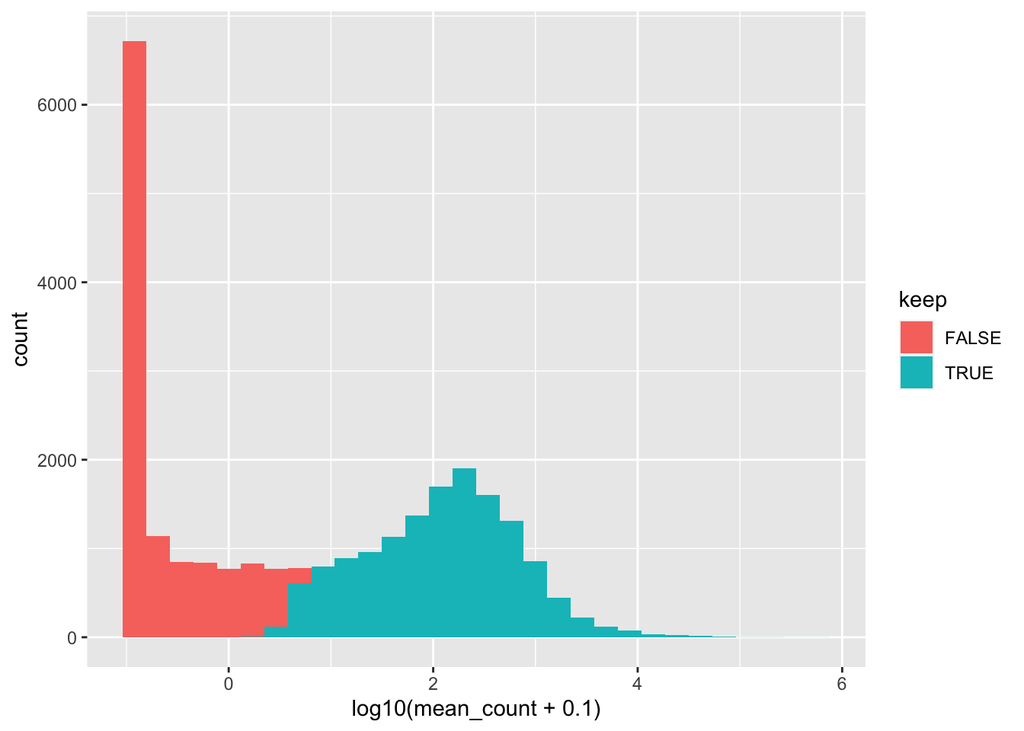

```r
raw_count_human_colon %>%
    gather(sample,count,starts_with("Sample_")) %>%
    group_by(entrezID, keep) %>%
    summarise(mean_count = mean(count)) %>%
    ggplot() + geom_histogram(aes(log10(mean_count+0.1), fill=keep))
```

In the next step we remove from the prior knowledge the genes that we dont keep. This will result a PKN for colon and SI separately

```r
expressed_genes_SI <- raw_count_human_SI %>%
    filter(keep_SI) %>%
    pull(entrezID)

meta_pkn_si <- filter_pkn_expressed_genes(expressed_genes_entrez = expressed_genes_SI,
                                          meta_pkn = meta_pkn)


expressed_genes_colon <- raw_count_human_colon %>%
    filter(keep_colon) %>%
    pull(entrezID)

meta_pkn_colon <- filter_pkn_expressed_genes(expressed_genes_entrez = expressed_genes_colon,
                                             meta_pkn = meta_pkn)
```

save results to files

```r
write_rds(meta_pkn_si,"./data/carnival_inputs/meta_pkn_si.rds")
write_rds(meta_pkn_colon,"./data/carnival_inputs/meta_pkn_colon.rds")
```